# RNAseAlert kit test 01

Jan Sklenar

27/03/2020

## Design

The idea is to test if the kit really works. Staring with the old kit (from Joe), only RNAse A used is from the new kit (from Josie). I also test Diethyl pyrocarbonate (DEPC), RNAse inhibitor. After the inhibitor is added and inhibiton is complete, Imidazole consumes surplus of the inhibitor. DEPC covalently modifies His, Lys, Cys, Tyr (be careful)!

#### Chemicals used in the reaction,

added in the following order in replicates of four, in squares on 96 well plate:

1. 20mM HEPES ph 7.0 buffer
2. RNAse A (fresh from the new kit), 0.01U/ml stock solution
3. DEPC (inhibitor), 0.1% in the reaction
4. Imidazole (inhibitor quencher), 10mM in the reaction
5. RNAse A (fresh enzyme after the background has been inhibited)
6. substrate (fluorescein-RNA conjugate), already diluted used only 2.5ul instead of sugested 10ul

#### Test conditions (volumes in microliters per well)

[figure not shown]

Copy of original table in Excel.

## Data preparation

```r
## show cleaned data with selected columns
#' Well, Sample, SampleNo, RepNo, MeasTimeSec, RFU
df <- raw[,c(3,6,11,12,7,8)]
head(df)
```

```
##   Well Sample SampleNo RepNo MeasTimeSec       RFU
## 1  A01  1 1/4        1     1        0.00  0.492376
## 2  B01  1 2/4        1     2        0.25  0.449980
## 3  C01  2 1/4        2     1        0.73 20.700400
## 4  D01  2 2/4        2     2        0.98 21.718400
## 5  E01  3 1/4        3     1        1.23 10.969500
## 6  F01  3 2/4        3     2        1.48 21.008800
```

```r
str(df)
```

```
## 'data.frame':    384 obs. of  6 variables:
##  $ Well       : chr  "A01" "B01" "C01" "D01" ...
##  $ Sample     : chr  "1 1/4" "1 2/4" "2 1/4" "2 2/4" ...
##  $ SampleNo   : chr  "1" "1" "2" "2" ...
##  $ RepNo      : chr  "1" "2" "1" "2" ...
##  $ MeasTimeSec: num  0 0.25 0.73 0.98 1.23 1.48 1.73 1.98 2.23 2.48 ...
##  $ RFU        : num  0.492 0.45 20.7 21.718 10.97 ...
```

## Plots

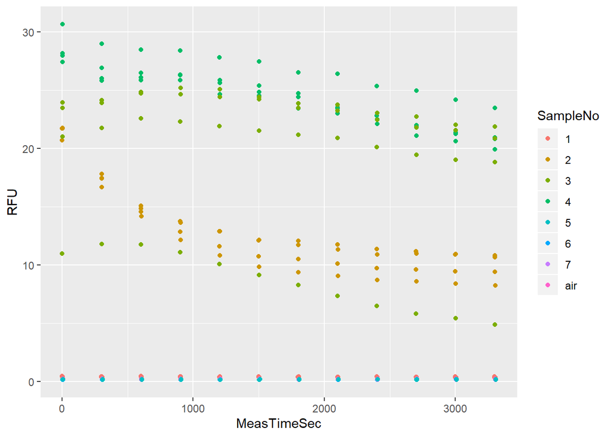

```r
#' all the data
#plot(x=raw$MeasTimeSec,y=raw$RFU)

#' colour labeled samples
ggplot(data = df) +
  aes(x = MeasTimeSec, y=RFU) +
  geom_point(aes(color=SampleNo))
```

```r
## Use summary statistics (mean) to find and remove obvious  outlier in  sample 3
#' means of all replicates of sample 3
dfstat <- df %>% filter(SampleNo==3) %>% group_by(SampleNo,RepNo) %>% summarise(mean=mean(RFU))
dfstat
```

```
## # A tibble: 4 x 3
## # Groups:   SampleNo [1]
##   SampleNo RepNo  mean
##   <chr>    <chr> <dbl>
## 1 3        1      8.59
## 2 3        2     20.9
## 3 3        3     23.7
## 4 3        4     23.3
```

```r
#' Data that should be removed
filter(df,SampleNo == 3 & RepNo == 1)
```

```
##    Well Sample SampleNo RepNo MeasTimeSec      RFU
## 1   E01  3 1/4        3     1        1.23 10.96950
## 2   E01  3 1/4        3     1      301.21 11.79530
## 3   E01  3 1/4        3     1      601.24 11.74910
## 4   E01  3 1/4        3     1      901.24 11.10680
## 5   E01  3 1/4        3     1     1201.22 10.07970
## 6   E01  3 1/4        3     1     1501.22  9.14433
## 7   E01  3 1/4        3     1     1801.24  8.27669
## 8   E01  3 1/4        3     1     2101.22  7.35878
## 9   E01  3 1/4        3     1     2401.47  6.48299
## 10  E01  3 1/4        3     1     2701.39  5.84216
## 11  E01  3 1/4        3     1     3001.43  5.43577
## 12  E01  3 1/4        3     1     3301.44  4.89816
```

```r
#' I could not invert the filter though
#' But it is the same as leaving out all the measurement from the well E01
dfs <- filter(df, Well != "E01")
#' all the measurements
length(rownames(df))
```

```
## [1] 384
```

```r
#'after 12 datapoints were removed
length(rownames(dfs))
```

```
## [1] 372
```

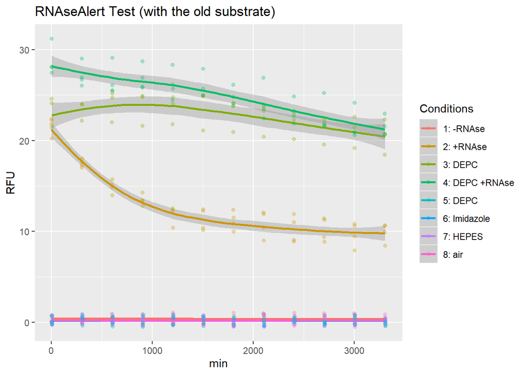

```r
## LOESS regression
p <- ggplot(data = dfs) +
  aes(x = MeasTimeSec, y=RFU) +
  geom_smooth(aes(color=SampleNo)) +
  geom_jitter(aes(color=SampleNo),width = 0.5, height = 0.7, alpha=0.3)

  p + labs(title = "RNAseAlert Test (with the old substrate)", x = "min", y = "RFU", color = "Legend Title\n") +
  scale_colour_discrete(name="Conditions",
                      breaks=c(1,2,3,4,5,6,7,"air"),
                      labels=c("1: -RNAse",
                               "2: +RNAse",
                               "3: DEPC",
                               "4: DEPC +RNAse",
                               "5: DEPC",
                               "6: Imidazole",
                               "7: HEPES",
                               "8: air"))
```

## Conclutions

### Good:

- All the negative controls are nearly zero.
- All the tests where RNAse A was added shows some RFU values.
- Kinetic measuremet shows the underlying problems.

### Not very good:

- Absolute intensity in positive controls is low.
- There is no gain of fluorescence over the time.
- Inhibition did not work. I think HEPES is the problem. PBS or MOPS should be used instead.
- In all coonditions where RNAse was present, the result is almost the same.
- It seem the reason could be not sufficient substrate concentration.
- The fluorescein was relesed instantaneously just after addition of RNAse. Thus at all observed time points we detected only a decay of the initially released fluorescence, instead of expected accumulation.
- Repeated measurement in 30 second interval gave the same result.
- It seems that chemicals added to inhibit RNAse A preserve the fluorescence signal, without DEPC and Imidazol the signal decays faster.
- When additinal RNAse was added to the negative control No.1 (buffer + substrate) a fluorescence signal was released, but did not increase over time.

### What next:

- Use more of the substrate.
- Use the new kit, with hopefully better substrate.
- Give the inhibitor more time, possibly higher concentraiton and or test a different buffer.

### Notes and references

- DEPC reacts with His (most strongly), Cys, Lys, Tyr, Ser, Thr. It also reacts with TRIS buffer amine. Somewhere mentione it reacts with HEPES and MOPS was recomended. Really? Morpholine is stable while piperazine not? At least PBS should be stable.
- Procedure for water: Add DEPC directly to the water to yield a 0.1 % solution. Shake vigorously and allow to set overnight at room temperature with the lid loose or incubated for 2 hours at 37 °C. The solution is then autoclaved 15 minutes for each liter.
- I diluted DEPC in Acetonitrile for low solubility in water. This is based on some proeomics papers on using DEPC as reagent for aminoacid residue modification: – [Mendosa 2008](https://europepmc.org/article/PMC/4232213) – [Zhou 2003](https://www.ncbi.nlm.nih.gov/pmc/articles/PMC3334416/)
- more links on DEPC
- [Sigma](https://www.sigmaaldrich.com/content/dam/sigma-aldrich/docs/Sigma/Product_Information_Sheet/d5758pis.pdf)
- [Berger (1975) Anal Biochem](https://www.sciencedirect.com/science/article/abs/pii/0003269775903152)